# PCA vs LDA

Monika Osiak, Anna Pręgowska, Patrycja Szczepaniak, Rafał Szulejko

15 04 2020

## Wstęp

Zadaniem było wykonanie analizy porównawczej metody wizualizacji PCA i LDA. Zadanie zostało wykonane na podstawie zbioru danych dotyczącego problemów z kręgosłupem. Zbiór posiada 2 klasy: normal i abnormal.

```r
head(spine)
```

|  | pelvic_incidence | pelvic_tilt | lumbar_lordosis_angle | sacral_slope | pelvic_radius | degree_spondylolisthesis | pelvic_slope | direct_tilt | thoracic_slope | cervical_tilt | sacrum_angle | scoliosis_slope | class | X |
| --- | --- | --- | --- | --- | --- | --- | --- | --- | --- | --- | --- | --- | --- | --- |
| 1 | 63.02782 | 22.552586 | 39.60912 | 40.47523 | 98.67292 | -0.254400 | 0.7445035 | 12.5661 | 14.5386 | 15.30468 | -28.658501 | 43.5123 | Abnormal | NA |
| 2 | 39.05695 | 10.060991 | 25.01538 | 28.99596 | 114.40543 | 4.564259 | 0.4151857 | 12.8874 | 17.5323 | 16.78486 | -25.530607 | 16.1102 | Abnormal | NA |
| 3 | 68.83202 | 22.218482 | 50.09219 | 46.61354 | 105.98514 | -3.530317 | 0.4748892 | 26.8343 | 17.4861 | 16.65897 | -29.031888 | 19.2221 | Abnormal | NA |
| 4 | 69.29701 | 24.652878 | 44.31124 | 44.64413 | 101.86850 | 11.211523 | 0.3693453 | 23.5603 | 12.7074 | 11.42447 | -30.470246 | 18.8329 | Abnormal | NA |
| 5 | 49.71286 | 9.652075 | 28.31741 | 40.06078 | 108.16872 | 7.918501 | 0.5433605 | 35.4940 | 15.9546 | 8.87237 | -16.378376 | 24.9171 | Abnormal | NA |
| 6 | 40.25020 | 13.921907 | 25.12495 | 26.32829 | 130.32787 | 2.230652 | 0.7899929 | 29.3230 | 12.0036 | 10.40462 | -1.512209 | 9.6548 | Abnormal | NA |

## PCA

Rozkład PCA dokonywany jest za pomocą metody `prcomp`.

```r
spine.pr <- prcomp(spine[c(1:12)],
                   center=TRUE,
                   scale=TRUE)
```

Następnie obliczamy wariancję w dwóch pierwszych składnikach wiodących.

```r
pc1_var <- as.double(summary(spine.pr)$importance[,1][2])
pc2_var <- as.double(summary(spine.pr)$importance[,2][2])
print(sprintf('Wariancja danych zawarta w pierwszym składniku wiodącym: %s%%',
              format(round(pc1_var, 2), nsmall = 2)))
```

```
## [1] "Wariancja danych zawarta w pierwszym składniku wiodącym: 0.27%"
```

```r
print(sprintf('Wariancja danych zawarta w drugim składniku wiodącym: %s%%',
              format(round(pc2_var, 2), nsmall = 2)))
```

```
## [1] "Wariancja danych zawarta w drugim składniku wiodącym: 0.10%"
```

Prezentacja pozostałych składników wiodących:

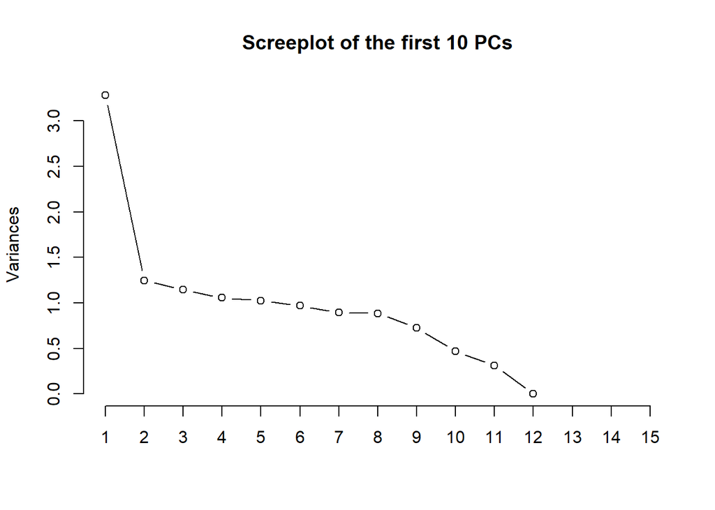

```r
screeplot(spine.pr,
          type="l",
          npcs=15,
          main="Screeplot of the first 10 PCs")
```

Zgodnie z oczekiwaniami, łączna wariancja kolejnych składników zbliża się do jedności.

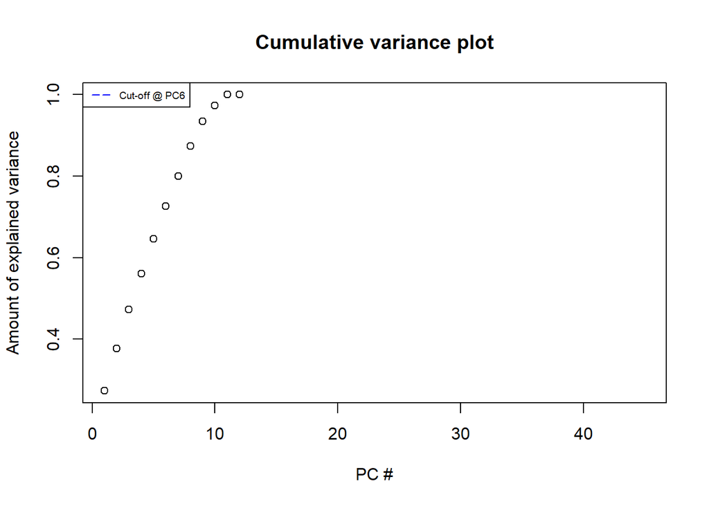

```r
cumpro <- cumsum(spine.pr$sdev^2 / sum(spine.pr$sdev^2))
plot(cumpro[0:45],
     xlab="PC #",
     ylab="Amount of explained variance",
     main="Cumulative variance plot")
legend("topleft",
       legend=c("Cut-off @ PC6"),
       col=c("blue"),
       lty=5,
       cex=0.6)
```

Po zredukowaniu danych do dwóch wymiarów otrzymujemy poniższy wykres:

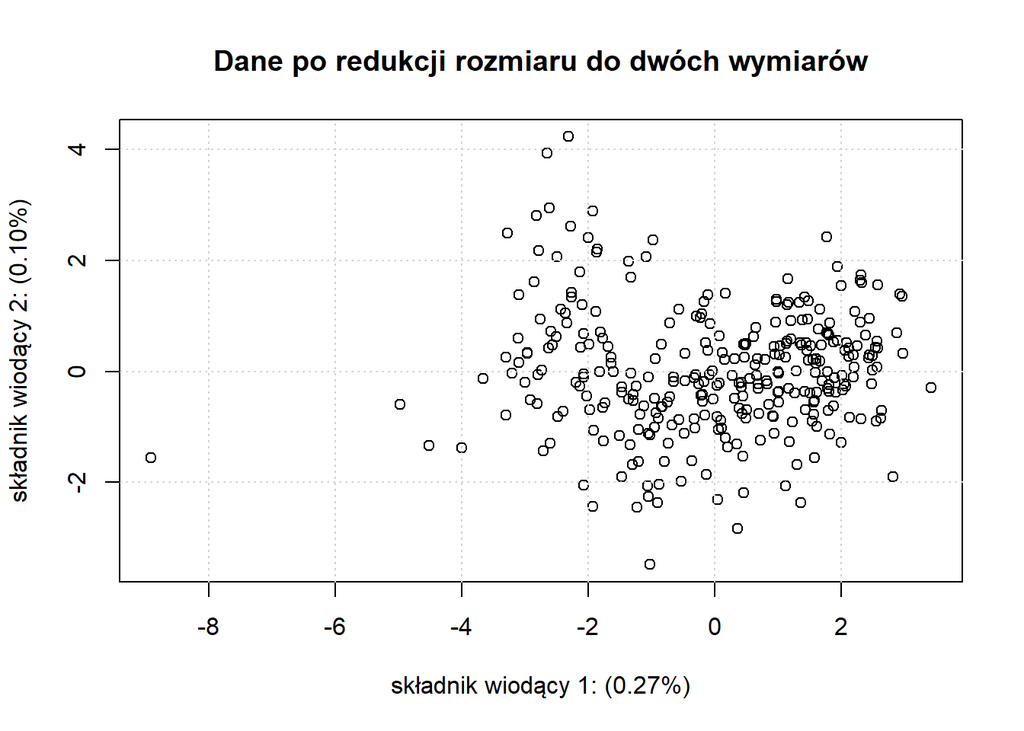

```r
x_label <- sprintf('składnik wiodący 1: (%s%%)', format(round(pc1_var, 2), nsmall = 2))
y_label <- sprintf('składnik wiodący 2: (%s%%)', format(round(pc2_var, 2), nsmall = 2))
plot_title <- 'Dane po redukcji rozmiaru do dwóch wymiarów'
plot(spine.pr$x[,1],
     spine.pr$x[,2],
     xlab=x_label,
     ylab=y_label,
     main=plot_title)
grid(nx=NULL,
     ny=NULL,
     col="lightgray",
     lty="dotted")
```

Ostateczny wynik uzyskujemy po podziale na klasy.

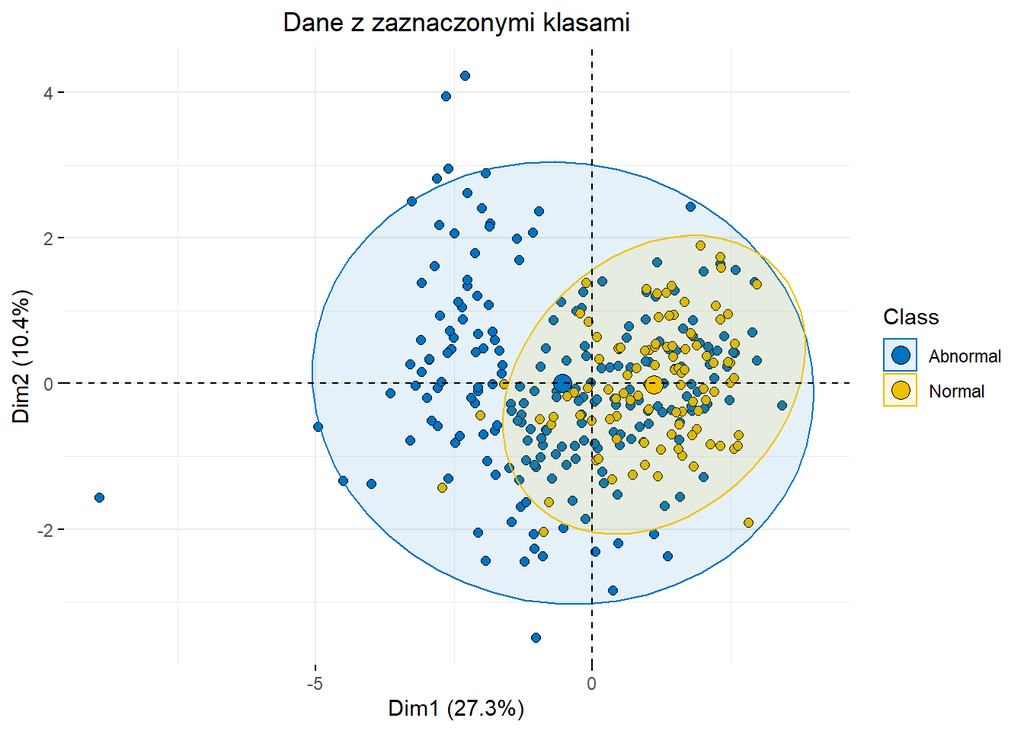

```r
fviz_pca_ind(spine.pr,
             geom.ind="point",
             pointshape=21,
             pointsize=2,
             fill.ind=spine$class,
             col.ind="black",
             palette="jco",
             addEllipses=TRUE,
             label="var",
             col.var="black",
             repel=TRUE,
             legend.title="Class") +
               ggtitle("Dane z zaznaczonymi klasami") +
               theme(plot.title=element_text(hjust=0.5))
```

## LDA

Rozkład LDA dokonywany jest za pomocą metody `lda`.

Dane zostały już wcześniej wczytane. Dlatego zaczynamy od podziału zbioru na treningowy (80%) i testowy (20%).

```r
set.seed(123)
training.samples <- spine$class %>%
  createDataPartition(p = 0.8, list = FALSE)

train.data <- spine[training.samples, ]
test.data <- spine[-training.samples, ]
```

Estymacja parametrów preprocesowania:

```r
preproc.param <- train.data %>%
  preProcess(method = c("center", "scale"))
```

Transformacja danych przy użyciu estymowanych parametrów:

```r
train.transformed <- preproc.param %>% predict(train.data)
test.transformed <- preproc.param %>% predict(test.data)
```

Dopasowanie modelu:

```r
model <- lda(formula=class~., data=train.transformed)
print(model)
```

```
## Call:
## lda(class ~ ., data = train.transformed)
##
## Prior probabilities of groups:
##  Abnormal    Normal
## 0.6774194 0.3225806
##
## Group means:
##          pelvic_incidence pelvic_tilt lumbar_lordosis_angle sacral_slope
## Abnormal        0.2552948   0.2239377             0.2241641    0.1572454
## Normal         -0.5361191  -0.4702692            -0.4707446   -0.3302154
##          pelvic_radius degree_spondylolisthesis pelvic_slope direct_tilt
## Abnormal    -0.2141769                0.2972055   0.04966127 -0.06114116
## Normal       0.4497715               -0.6241315  -0.10428866  0.12839644
##          thoracic_slope cervical_tilt sacrum_angle scoliosis_slope
## Abnormal    -0.03356915     0.1182273  0.009774058     -0.01991401
## Normal       0.07049522    -0.2482772 -0.020525521      0.04181943
##
## Coefficients of linear discriminants:
##                                  LD1
## pelvic_incidence          0.10301767
## pelvic_tilt              -0.33603032
## lumbar_lordosis_angle    -0.31775755
## sacral_slope              0.34693440
## pelvic_radius             0.76782374
## degree_spondylolisthesis -0.81587296
## pelvic_slope             -0.08451518
## direct_tilt               0.05216768
## thoracic_slope            0.03533727
## cervical_tilt            -0.23035786
## sacrum_angle              0.00179666
## scoliosis_slope           0.04000780
```

Prezentacja modelu z podziałem na klasy.

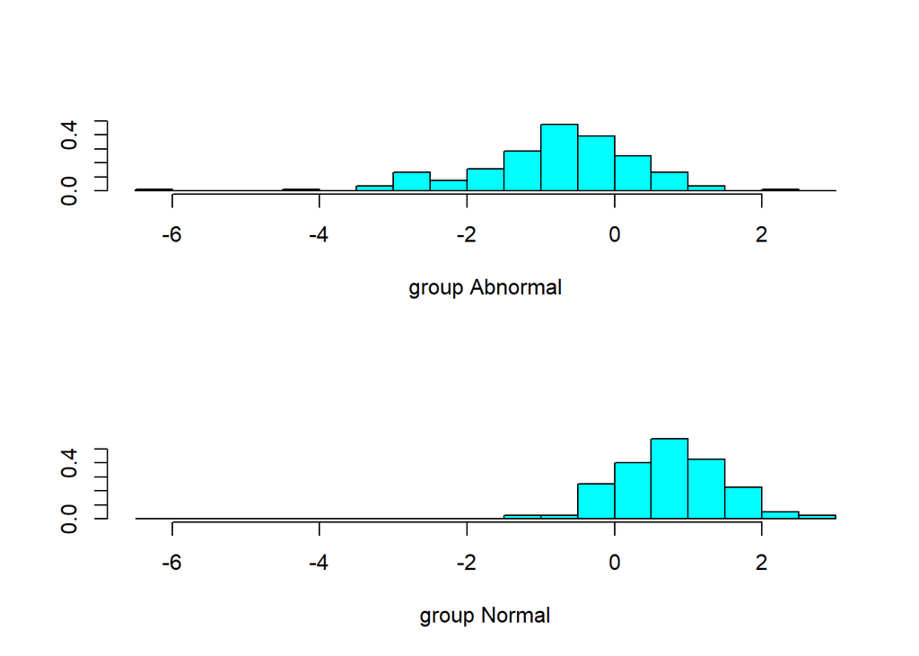

```r
plot(model)
```

Wykonanie predykcji:

```r
predictions <- model %>% predict(train.transformed)
```

Wyznaczenie precyzji predykcji modelu:

```r
mean(predictions$class==test.transformed$class)
```

```
## [1] 0.6330645
```

Wizualizacja funkcji dyskryminacji:

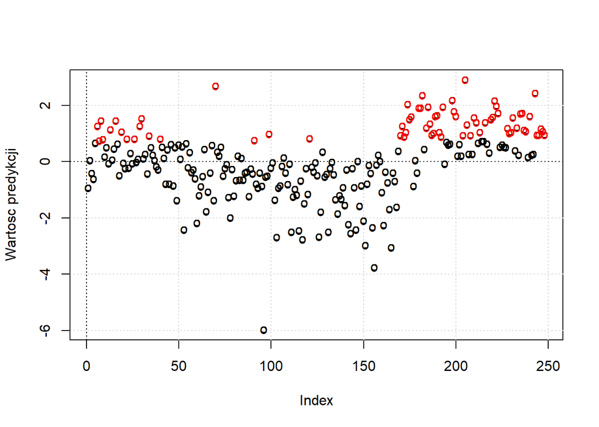

```r
plot_title <- ''
plot(predictions$x[,1],
     ylab="Wartosc predykcji",
     main=plot_title)
grid(nx=NULL,
     ny=NULL,
     col="lightgray",
     lty="dotted")
text(predictions$x[,1], label="o", col=c(as.numeric(predictions$class)))
abline(v=0, lty="dotted")
abline(h=0, lty="dotted")
```

Wizualizacja współczynników modelu:

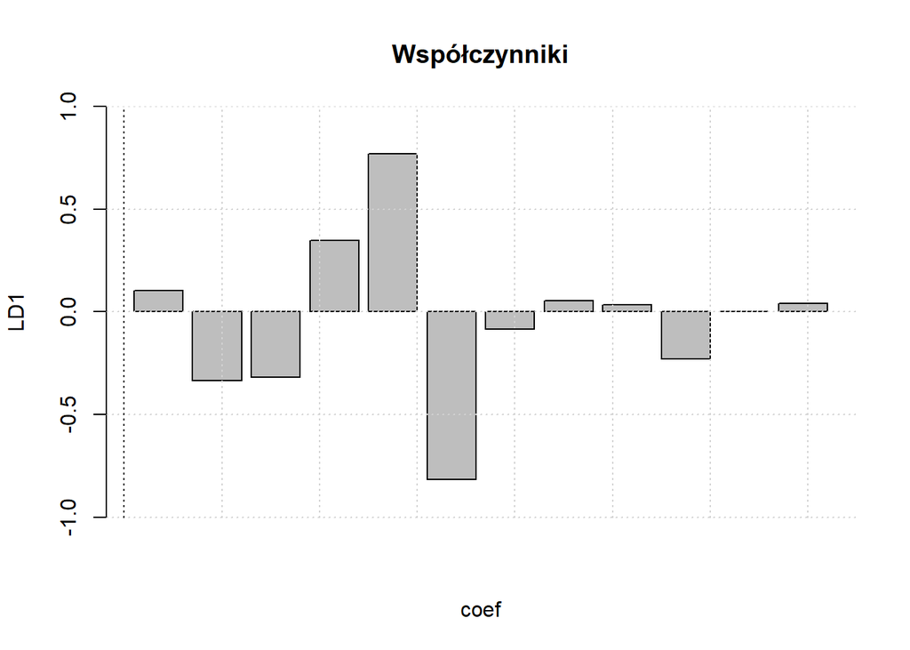

```r
plot_title <- 'Współczynniki'
barplot(c(coef(model)), main=plot_title, xlab = "coef", ylab = "LD1", ylim=c(-1,1))
grid(nx=NULL,
     ny=NULL,
     col="lightgray",
     lty="dotted")
abline(v=0, lty="dotted", col=c(as.numeric(predictions$class)))
```

## Wnioski

1. Podstawową różnicą między omawianymi metodami jest to, że LDA jest metodą nadzorowaną (występuje wstępny podział na klasy), natomiast PCA jest nienadzorowana (nie posiada wstępnego podziału).
2. Algorytm PCA opiera się na jednej macierzy kowariancji, natomiat LDA korzysta z macierzy opisujących zmienność wewnątrzgrupową i międzygrupową.
3. Wybraliśmy niestety zbiór, który okazał się trudny do skutecznej liniowej eliminacji wymiarów, jednak dla naszego modelu LDA lepiej sklasyfikowało dane.
4. LDA zapewnia lepszą separację klas niż PCA. Dzieje się tak dlatego, że PCA skupia się przede wszystkim na śledzeniu wariancji danych, natomiast LDA na wariancjach międzyklasowych.
5. LDA wymaga wcześniejszego preprocesowania danych, przez co jest trudniejsze w implementacji.
6. Dla metody LDA największy wpływ na klasyfikację miały atrybuty pelvic_radius oraz degree_spondylolisthesis.
7. Przypuszczamy, że w większości sytuacji metoda LDA powinna dawać lepsze wyniki, jednakże wszystko zależy od omawianego przypadku i do każdego należy podejść indywidualnie.
8. Metody PCA i LDA nie muszą konkurować, można wykorzystać obie, żeby uzyskać szerszą perspektywę i zrozumienie zagadnienia.